# compressor_fouling_with_uncertanity

```python
%load_ext autoreload
%autoreload 2
```

```python
import os
from pathlib import Path
from typing import cast
import warnings

import arviz_plots as azp
import arviz_stats as azs
import matplotlib.pyplot as plt
import numpy as np
import pandas as pd
import pymc as pm
from sklearn.linear_model import LinearRegression
from sklearn.metrics import r2_score

from compressor_fouling_modeling.utility import (
    CoefficientStructure,
    CoefPrior,
    InterceptStructure,
    LikeLiHood,
    NoiseStructure,
    build_and_fit_bayesian_models,
    calculate_cusum_with_uncertainty,
    calculate_empirical_sigma_stats,
    check_likelihood_qqplot,
    compare_and_select_best_model,
    compute_exceedance_probability,
    compute_masked_statistics,
    compute_psis_weights,
    evaluate_model_elpd,
    evaluate_model_performance,
    evaluate_noise_model,
    exctract_pymc_groups_data,
    plot_loo_calibration_curves,
    plot_posterior_predictive,
    plot_predictions_with_uncertainty,
    prepare_bayesian_model_args,
    prepare_hierarchical_noise_args,
    visualize_density_clusters,
    visualize_probabilistic_cusum,
)

os.environ["XLA_PYTHON_CLIENT_ALLOCATOR"] = "platform"  # makes JAX allocate exactly what is needed on demand
# azb.rcParams to check default parameters in arviz base
# azp.style.available() to check available stylesof interest
azp.style.use("dark_background")  # pick style of interest
%config InlineBackend.figure_format = 'retina'  # high resolution figures
warnings.filterwarnings("ignore")
```

```python
RANDOM_SEED = 14
rng = np.random.default_rng(RANDOM_SEED)
```

```python
# Define project root relative to notebook location
PROJECT_ROOT = Path().resolve().parents[0]  # goes up one level from /notebooks/
IMAGE_DIR = Path(PROJECT_ROOT / "results" / "plots")
DATA_DIR = PROJECT_ROOT / "data"
```

```python
# Check if the directory exists and create it if it doesn't
if not IMAGE_DIR.exists():
    try:
        IMAGE_DIR.mkdir(parents=True, exist_ok=True)
        print(f"Directory '{IMAGE_DIR}' created successfully.")
    except Exception as e:
        print(f"An error occurred: {e}")
else:
    print(f"Directory '{IMAGE_DIR}' already exists.")
```

```
Directory '/home/mghanava/Projects/DataScience/projects/compressor_fouling_modeling/results/plots' already exists.
```

```python
X_baseline = pd.read_csv(DATA_DIR / "processed" / "X_baseline.csv", index_col=0, parse_dates=True).squeeze("columns")
y_baseline = pd.read_csv(DATA_DIR / "processed" / "y_baseline.csv", index_col=0, parse_dates=True).squeeze("columns")
X = pd.read_csv(DATA_DIR / "processed" / "X_full.csv", index_col=0, parse_dates=True).squeeze("columns")
y = pd.read_csv(DATA_DIR / "processed" / "y_full.csv", index_col=0, parse_dates=True).squeeze("columns")
baseline_mask = pd.read_csv(DATA_DIR / "processed" / "baseline_mask.csv", index_col=0, parse_dates=True).squeeze("columns")
shutin_mask = pd.read_csv(DATA_DIR / "processed" / "shutin_mask.csv", index_col=0, parse_dates=True).squeeze("columns")
```

# Bayesian Approach

```python
setpoint_unique, setpoint_index, map_sp_to_idx = prepare_hierarchical_noise_args(
    X_baseline
)
empirical_stats, mean_std, range_to_mean_ratio, min_std, max_std = (
    calculate_empirical_sigma_stats(X_baseline, y_baseline, setpoint_unique.tolist())
)
std_unscaled = {sp: empirical_stats[sp]["std"] for sp in empirical_stats}
```

```
Empirical Standard Deviations by Setpoint:
============================================================
Setpoint 80.0 psi: sigma_unscaled = 2.700 (n=39)
Setpoint 100.0 psi: sigma_unscaled = 2.824 (n=28)
Setpoint 140.0 psi: sigma_unscaled = 3.045 (n=34)
Setpoint 180.0 psi: sigma_unscaled = 2.952 (n=29)

============================================================
Overall: weighted mean sigma_unscaled = 2.873, range normalized by mean = 12.00% spread around mean = [-6.02%, 5.97%]
```

```
Prepare the dataset for regressing outlet-pressure residuals against their respective setpoints.
autocorrelation changed from original 0.9661561858376039 to 0.03004635898746591.

Roughly 0.072 of variance can be explained by features altogether after removing outlet_pressure_sp.
```

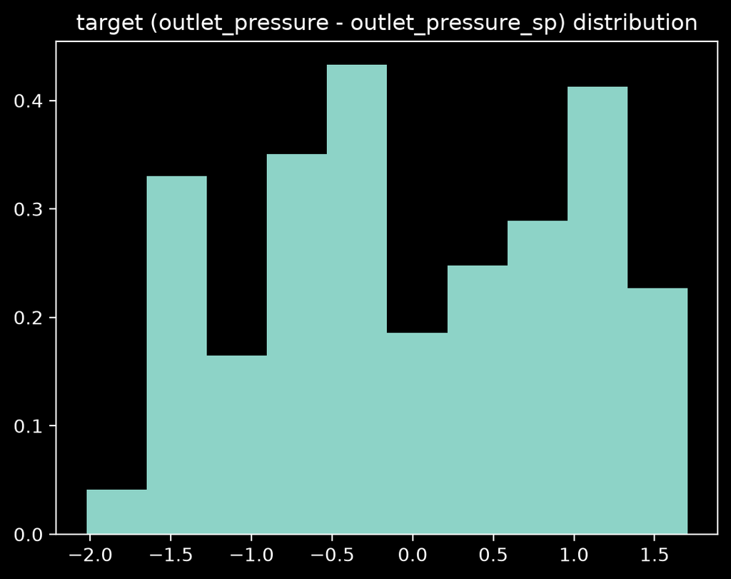

```python
print(
    "Prepare the dataset for regressing outlet-pressure residuals against their"
    " respective setpoints."
)
data_residual = prepare_bayesian_model_args(
    X_baseline, y_baseline, shuffle_baseline=False, residual_target=True
)
lr = LinearRegression()
lr.fit(data_residual.X_scaled, data_residual.y_scaled)
y_pred = lr.predict(data_residual.X_scaled)
r2 = r2_score(data_residual.y_scaled, y_pred)
print(
    f"\nRoughly {r2:.3f} of variance can be explained by features altogether after"
    " removing outlet_pressure_sp."
)

fig, ax = plt.subplots(1, 1)
ax.hist(data_residual.y_scaled, density=True)
ax.set_title("target (outlet_pressure - outlet_pressure_sp) distribution")
plt.show()
plt.close(fig)
del fig, ax
```

The problem that we are trying to solve is:

$$\textbf{\textit{outlet\_pressue}} = \textbf{\textit{noise}} + \textbf{\textit{intercept}} + \textbf{\textit{outlet\_pressure\_SP}} \times \beta_{outlet\_pressure\_sp} + \textbf{\textit{Inlet\_Temperature}} \times \beta_{Inlet\_Temperature} + \dots$$

The correct approach is to regress $\textit{outlet\_pressue}$ on all predictors as stated above and find the respective $\beta$ of each predictor. However we know in a controlled system like separator, the setpoints are dominant variables. For example, the $\textit{outlet\_pressue}$ for the most part should follow $\textit{outlet\_pressure\_sp}$. Thus one may mistakenly consider $\beta_{outlet\_pressure\_sp}=1$ and regress on other variables in two ways:

1. Consider $\textbf{\textit{outlet\_pressure\_SP}}$ as an offset on the righ-hand-side of equation and consider all other predictors adjust this offset to match $\textbf{\textit{outlet\_pressue}}$ changes.
2. Move $\textbf{\textit{outlet\_pressure\_SP}}$ to the left-hand-side and in fact model the direct resdiuals $\textbf{\textit{outlet\_pressue}} - \textbf{\textit{outlet\_pressure\_SP}}$ using remaining predictors.

We do not follow these two approaches because:

1. Considering $\beta_{outlet\_pressure\_sp}=1$ introduces bias if the value is not in fact very close to 1 which is most likley the case.
2. Although we expect the $\beta_{outlet\_pressure\_sp}$ not to be 1, it should be very high as it is the nature of such controlled processes. Thus, removing it from predictors reduces variance in data significantly which results in model under performance.

```python
print("\nPrepare the dataset for regressing outlet-pressure directly.")
data_out_pressure = prepare_bayesian_model_args(
    X_baseline, y_baseline, shuffle_baseline=True, random_seed=RANDOM_SEED
)
```

```
Prepare the dataset for regressing outlet-pressure directly.
autocorrelation changed from original 0.9661561858376039 to 0.05278415596673178.
```

```
Cluster centers through KDE peaks: [-1.109 -0.571  0.468  1.506]
Cluster centers through GMM method: [-1.104, -0.569, 0.464, 1.49]
```

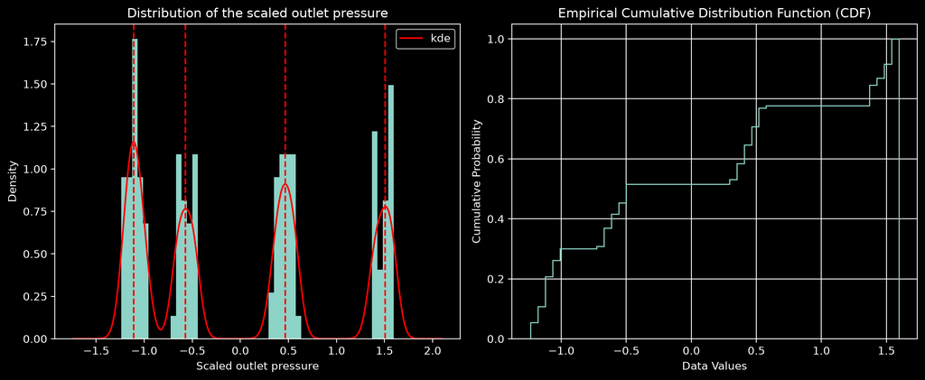

```python
visualize_density_clusters(
    data_out_pressure.y_scaled.to_numpy(),
    bound_width=mean_std / data_out_pressure.y_std,
    hist_bins=50,
)
```

```python
noise_kwargs = {
    "sigma_mu_mu": mean_std / data_out_pressure.y_std,
    "sigma_mu_sd": np.log(1 + 1.0 * range_to_mean_ratio),  # ~12% variation around
    # mean according to np.exp(sigma_mu_sd)
}

hierarchical_noise_kwargs = {
    "setpoint_unique": setpoint_unique,
    "setpoint_index": setpoint_index,
    "sigma_sd_sd": np.log(
        1 + 1.5 * range_to_mean_ratio
    ),  # ~18% between-setpoint variation (24% total multiplicative uncertanity
    # according to exp(sqrt(0.12**2+0.18**2)))
}

coef_kwargs = {"mu": 0.0, "sd": 0.25}
likelihood_model_kwargs = {"alpha": 5.0, "beta": 0.25}  # for T-student likelihood

# Define model configurations
model_configs = [
    {
        "name": "non_hierarchical",
        "X": data_out_pressure.X_scaled,
        "y": data_out_pressure.y_scaled,
    },
    {
        "name": "all_hierachical",
        "X": data_out_pressure.X_scaled,
        "y": data_out_pressure.y_scaled,
        "has_setpoint_coords": True,
        "noise_structure": NoiseStructure.HIERARCHICAL,
        "intercept_structure": InterceptStructure.HIERARCHICAL,
        "coefficient_structure": CoefficientStructure.HIERARCHICAL,
    },
    {
        "name": "all_hierachical_but_coefficients",
        "X": data_out_pressure.X_scaled,
        "y": data_out_pressure.y_scaled,
        "has_setpoint_coords": True,
        "noise_structure": NoiseStructure.HIERARCHICAL,
        "intercept_structure": InterceptStructure.HIERARCHICAL,
    },
    {
        "name": "hierarchical_noise",
        "X": data_out_pressure.X_scaled,
        "y": data_out_pressure.y_scaled,
        "has_setpoint_coords": True,
        "noise_structure": NoiseStructure.HIERARCHICAL,
    },
    {
        "name": "hierarchical_intercept",
        "X": data_out_pressure.X_scaled,
        "y": data_out_pressure.y_scaled,
        "has_setpoint_coords": True,
        "intercept_structure": InterceptStructure.HIERARCHICAL,
    },
    {
        "name": "non_hierarchical_laplace_prior",
        "X": data_out_pressure.X_scaled,
        "y": data_out_pressure.y_scaled,
        "coef_prior": CoefPrior.LAPLACE,
    },
    {
        "name": "all_hierachical_but_coefficients_laplace_prior",
        "X": data_out_pressure.X_scaled,
        "y": data_out_pressure.y_scaled,
        "has_setpoint_coords": True,
        "noise_structure": NoiseStructure.HIERARCHICAL,
        "intercept_structure": InterceptStructure.HIERARCHICAL,
        "coef_prior": CoefPrior.LAPLACE,
    },
    {
        "name": "non_hierarchical_laplace_prior_t_Likelihood",
        "X": data_out_pressure.X_scaled,
        "y": data_out_pressure.y_scaled,
        "coef_prior": CoefPrior.LAPLACE,
        "likelihood_model": LikeLiHood.T,
    },
]

# Common parameters for all models
common_params = {
    "intercept_sd": 0.4,
    "coef_kwargs": coef_kwargs,
    "noise_kwargs": noise_kwargs,
    "hierarchical_kwargs": hierarchical_noise_kwargs,
    "likelihood_model_kwargs": likelihood_model_kwargs,
    "random_seed": RANDOM_SEED,
}

model_dict, idatas_dict = build_and_fit_bayesian_models(model_configs, common_params)
```

```
Model non_hierarchical built successfully!
```

```
Sampling: [beta, intercept, log_sigma, y_like]
Sampling: [y_like]
```

```
Output()
```

```
Model non_hierarchical fitted successfully!

Model all_hierachical built successfully!
```

```
Sampling: [beta_mu, beta_raw, beta_sd, intercept, log_sigma_mu, log_sigma_raw, log_sigma_sd, mu_intercept, sigma_intercept, y_like]
Sampling: [y_like]
```

```
Output()
```

```
Model all_hierachical fitted successfully!

Model all_hierachical_but_coefficients built successfully!
```

```
Sampling: [beta, intercept, log_sigma_mu, log_sigma_raw, log_sigma_sd, mu_intercept, sigma_intercept, y_like]
Sampling: [y_like]
```

```
Output()
```

```
Model all_hierachical_but_coefficients fitted successfully!

Model hierarchical_noise built successfully!
```

```
Sampling: [beta, intercept, log_sigma_mu, log_sigma_raw, log_sigma_sd, y_like]
Sampling: [y_like]
```

```
Output()
```

```
Model hierarchical_noise fitted successfully!

Model hierarchical_intercept built successfully!
```

```
Sampling: [beta, intercept, log_sigma, mu_intercept, sigma_intercept, y_like]
Sampling: [y_like]
```

```
Output()
```

```
Model hierarchical_intercept fitted successfully!

Model non_hierarchical_laplace_prior built successfully!
```

```
Sampling: [beta, intercept, log_sigma, tau, y_like]
Sampling: [y_like]
```

```
Output()
```

```
Model non_hierarchical_laplace_prior fitted successfully!

Model all_hierachical_but_coefficients_laplace_prior built successfully!
```

```
Sampling: [beta, intercept, log_sigma_mu, log_sigma_raw, log_sigma_sd, mu_intercept, sigma_intercept, tau, y_like]
Sampling: [y_like]
```

```
Output()
```

```
Model all_hierachical_but_coefficients_laplace_prior fitted successfully!

Model non_hierarchical_laplace_prior_t_Likelihood built successfully!
```

```
Sampling: [beta, intercept, log_sigma, nu, tau, y_like]
Sampling: [y_like]
```

```
Output()
```

```
Model non_hierarchical_laplace_prior_t_Likelihood fitted successfully!
```

```python
model_top, idata_top = compare_and_select_best_model(model_dict, idatas_dict)
```

|  | rank | elpd_diff | dse | p_worse | diag_diff | diag_elpd | p | elpd | se | weight |
| --- | --- | --- | --- | --- | --- | --- | --- | --- | --- | --- |
| non_hierarchical_laplace_prior | 0 | 0.00 | 0.00 | NaN |  |  | 9.71 | 148.60 | 5.31 | 0.44 |
| all_hierachical_but_coefficients_laplace_prior | 1 | -1.17 | 0.72 | 0.95 | \|elpd_diff\| < 4 |  | 11.64 | 147.43 | 5.40 | 0.15 |
| non_hierarchical | 2 | -1.52 | 0.89 | 0.96 | \|elpd_diff\| < 4 |  | 10.35 | 147.08 | 5.45 | 0.11 |
| non_hierarchical_laplace_prior_t_Likelihood | 3 | -1.73 | 0.19 | 1.00 | \|elpd_diff\| < 4 |  | 9.98 | 146.87 | 5.33 | 0.08 |
| hierarchical_noise | 4 | -1.97 | 0.95 | 0.98 | \|elpd_diff\| < 4 |  | 10.95 | 146.63 | 5.49 | 0.07 |
| hierarchical_intercept | 5 | -2.66 | 1.08 | 0.99 | \|elpd_diff\| < 4 |  | 11.81 | 145.94 | 5.47 | 0.04 |
| all_hierachical_but_coefficients | 6 | -2.91 | 1.18 | 0.99 | \|elpd_diff\| < 4 |  | 12.32 | 145.69 | 5.54 | 0.03 |
| all_hierachical | 7 | -5.16 | 3.70 | 0.92 |  |  | 24.32 | 143.44 | 5.87 | 0.07 |

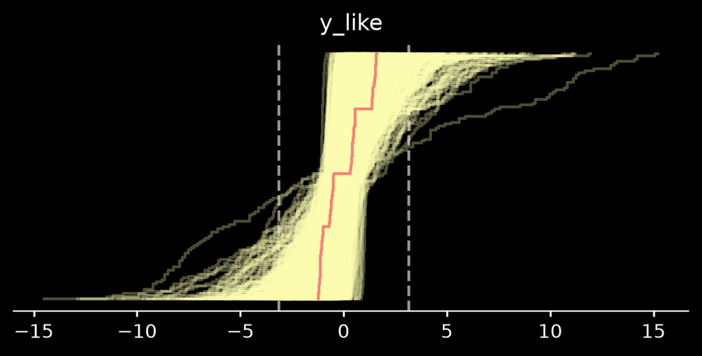

```python
# prior knowledge
y_min = 5  # minimum plausible compressor pressure (psi)
y_max = 250  # maximum plausible compressor pressure (psi)
# check if prior is not too far from the data distribution
pc = azp.plot_ppc_dist(
    idata_top,
    group="prior_predictive",
    kind="ecdf",
    visuals={"predictive_dist": {"color": "C1"}, "observed_dist": {"color": "C3"}},
    num_samples=1000,
)
azp.add_lines(
    pc,
    values=(
        (y_min - data_out_pressure.y_mean) / data_out_pressure.y_std,
        (y_max - data_out_pressure.y_mean) / data_out_pressure.y_std,
    ),
)
pc.show()
```

```python
node_formatters = {
    "Free Random Variable": lambda var: {"shape": "circle", "label": var.name},
    "Observed Random Variable": lambda var: {"shape": "square", "label": var.name},
}
pm.model_to_graphviz(
    model_top,
    node_formatters=node_formatters,  # type: ignore
)
```

[figure not shown]

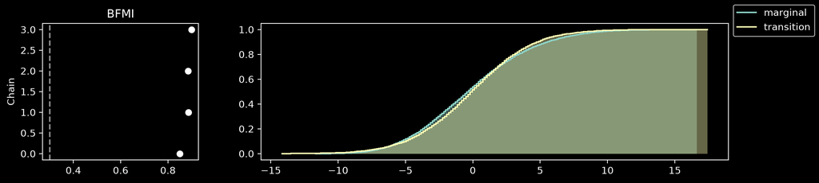

```python
pc = azp.plot_energy(idata_top, kind="ecdf")
```

# Warning not to use ArviZ KDE in multimodal distribution

What ArviZ KDE Does

Step 1: For posterior draw s, take 130 predictive samples ỹ_i ~ Normal(μ_i^(s), σ^(s))

Step 2: Apply KDE to these 130 points → KDE auto-selects bandwidth based on overall data spread

The problem is in Step 2. Standard bandwidth selectors (Scott/Silverman) assume unimodal data:

Silverman's rule bw = 0.9 * min(std, IQR/1.34) * n**(-1/5) data: std ≈ 1.0, n = 130 bw ≈ 0.9 * 1.0 * 130**(-0.2) ≈ 0.34

So the KDE uses bandwidth ≈ 0.34, while the actual within-cluster spread is σ = 0.074:

KDE bandwidth: 0.34 ← smears clusters together Actual σ: 0.074 ← sharp, separated clusters

KDE is ~5× wider than reality!

```python
# ecdf is more informative here than the default kde as it is not bandwidth
# sensitive and the data distribution is not unimodal normal
# band_width = mean_std / data_out_pressure.y_std
# pc = azp.plot_ppc_dist(
#     idata_top,
#     kind="kde",
#     stats={"predictive_dist": {"bw": band_width}, "observed_dist": {"bw": band_width}},
#     num_samples=1000,
#     figure_kwargs={"figsize": (10, 5)},
# )
```

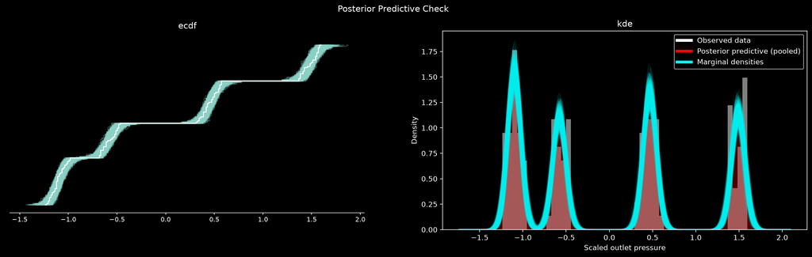

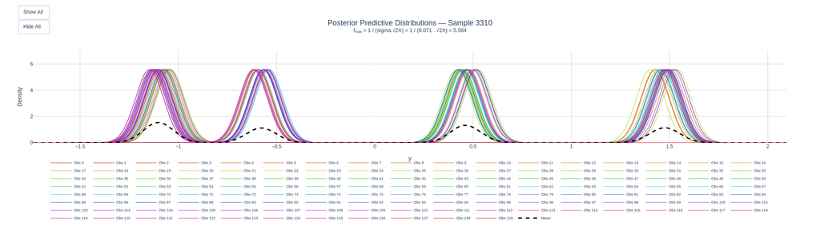

```python
fig_ppc_ecdf_kde, fig_ppc_obs_kde = plot_posterior_predictive(
    idata_top, random_seed=RANDOM_SEED
)
```

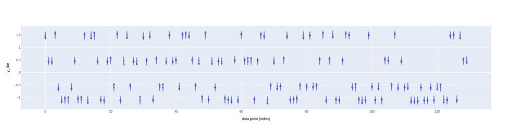

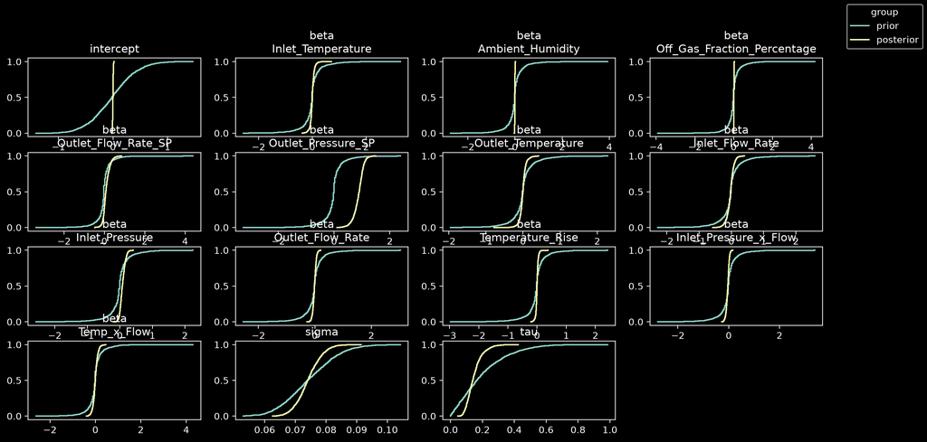

```python
pc = azp.plot_prior_posterior(
    idata_top,
    var_names=["intercept", "beta", "sigma", "tau"],
    kind="ecdf",
)
pc = azp.plot_ppc_interval(
    idata_top,
    ci_kind="hdi",
    ci_probs=(0.925, 0.975),
    figure_kwargs={"figsize": (10, 5)},
    backend="plotly",
)
pc.show()
```

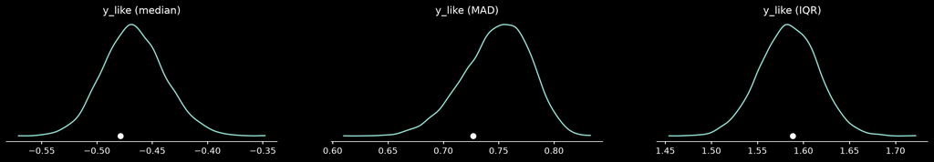

```python
pc = azp.combine_plots(
    idata_top,
    plots=[
        (azp.plot_ppc_tstat, {"t_stat": "median"}),
        (azp.plot_ppc_tstat, {"t_stat": "mad"}),
        (azp.plot_ppc_tstat, {"t_stat": "iqr"}),
    ],
    group="posterior_predictive",
)
```

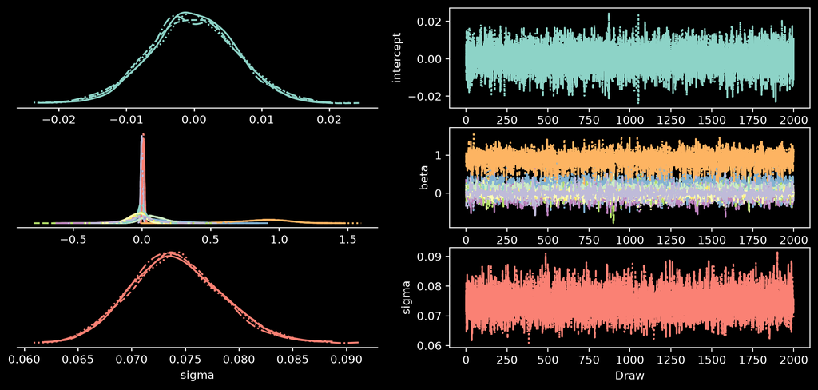

```python
pc = azp.plot_trace_dist(
    idata_top,
    var_names=["intercept", "beta", "sigma"],
    compact=True,
    combined=False,
)
```

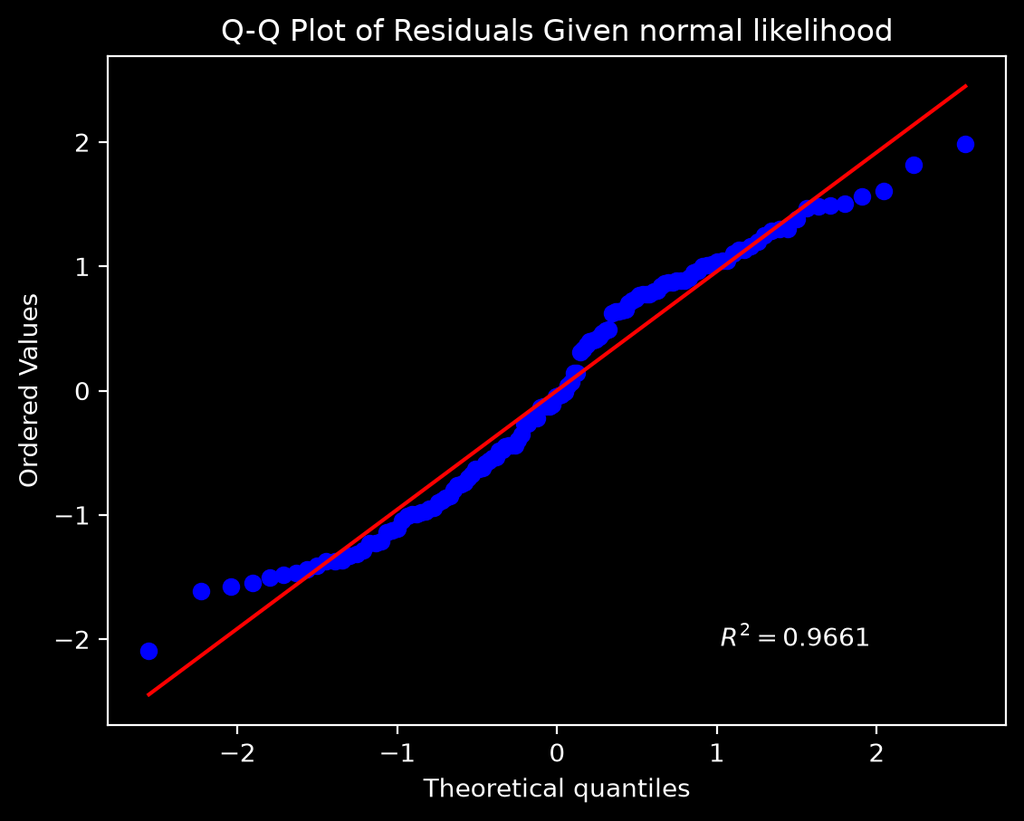

```python
qqplot_normal_likelihhod = check_likelihood_qqplot(
    idata_top, "normal", data_out_pressure.y_scaled.to_numpy()
)
```

The Q-Q plot shows:

What the slight tail deviations mean:

The few points deviating at the extremes (one at ~-2.1 and a couple at ~+1.8 to +2.0) suggest very slight heavy tails, but this is extremely minor. In practice, this level of deviation is:

Well within acceptable bounds for real-world data

Not significant enough to warrant switching to Student's t Could just be natural sampling variability with only 130 observations

Conclusion:

The Normal likelihood is well-justified. The residuals are approximately normally distributed, which validates the modeling choice. You don't need to change to a more complex likelihood (Student's t, mixture, etc.).

```python
idata_top_data = exctract_pymc_groups_data(idata_top)
```

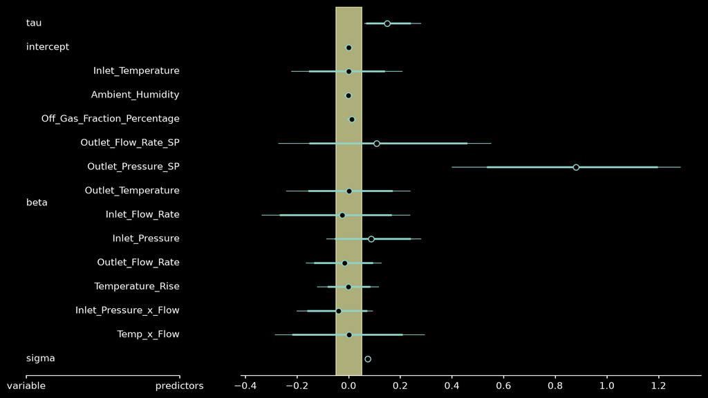

```python
rope = [(-0.05, 0.05)]
pc = azp.plot_forest(
    idata_top,
    var_names=["tau", "intercept", "beta", "sigma"],
    combined=True,
    ci_kind="hdi",
    ci_probs=(0.925, 0.975),
)
pc.coords = {"column": "forest"}
pc = azp.add_bands(
    pc,
    values=rope,
    visuals={"ref_band": {"color": "C1"}},
)
```

```python
# pc = azp.plot_loo_pit(idata_top, coverage=True, figure_kwargs={"figsize": (6, 3)})
out_pressure_loo = azs.loo(idata_top, pointwise=True)
out_pressure_loo
```

```
Computed from 8000 posterior samples and 130 observations log-likelihood matrix.

         Estimate       SE
elpd_loo   148.60     5.35
p_loo        9.71        -
------

Pareto k diagnostic values:
                         Count   Pct.
(-Inf, 0.70]   (good)      130  100.0%
   (0.70, 1]   (bad)         0    0.0%
    (1, Inf)   (very bad)    0    0.0%
```

```python
with model_top:
    print(f"list of free (unconstrained) variables: {model_top.free_RVs}")
    # For total scalar count:
    n_params = sum(rv.size.eval() for rv in model_top.free_RVs)
    print(f"Total scalar parameters: {n_params}")
```

```
list of free (unconstrained) variables: [intercept, tau, beta, log_sigma]
Total scalar parameters: 15
```

```python
# elpd_in_sample = Σ_i log[E_post(p(y_i|θ))]
elpd_in_sample = np.log(
    np.exp(idata_top.log_likelihood["y_like"]).stack(s=("chain", "draw")).mean(dim="s")  # noqa: PD013 - stack() required for xarray dimension stacking
).sum()

# from scipy.stats import norm

# idata = trace_out_pressure
# ## Extract posterior samples
# mu_samples = idata.posterior["mu"].values.reshape(-1, 130)  # (S, N)
# sigma_samples = np.exp(idata.posterior["log_sigma"].values.reshape(-1, 1))  # (S, 1)
# S = mu_samples.shape[0]  # 8000 samples
# # For each observation, compute average likelihood over posterior samples
# # then take log — this is the exact MCMC approximation of ELPD
# log_avg_likelihood = np.zeros(130)
# for i in range(130):
#     # p(y_i | theta^j) for all j
#     likelihoods = norm.pdf(
#         y_obs.to_numpy()[i], loc=mu_samples[:, i], scale=sigma_samples[:, 0]
#     ) # (chain * draw, N)
#     # average over S samples (chain * draw), then log
#     log_avg_likelihood[i] = np.log(np.mean(likelihoods))

# elpd_in_sample = np.sum(log_avg_likelihood)

optimism = elpd_in_sample - out_pressure_loo.elpd
optimism_ratio = optimism / len(data_out_pressure.y_scaled)

print(f"in-sample ELPD:                            {elpd_in_sample:.2f}")
print(f"LOO ELPD (out-of-sample):                  {out_pressure_loo.elpd:.2f}")
print(f"Total optimism (overfitting tendency) or p-loo:         {optimism:.2f}")
print(
    "individual contributions of each observation to the overfitting tendency: "
    f"{optimism_ratio * 100:.2f}%"
)
```

```
in-sample ELPD:                            158.31
LOO ELPD (out-of-sample):                  148.60
Total optimism (overfitting tendency) or p-loo:         9.71
individual contributions of each observation to the overfitting tendency: 7.47%
```

# Understanding the Expected Log Pointwise Predictive Density (elpd_loo)

## 1. Definition

The **Expected Log Pointwise Predictive Density** using Leave-One-Out cross-validation (elpd_loo) is defined as:

$$\text{elpd\_loo} = \sum_{i=1}^{n} \log p(y_i \mid y_{-i})$$

where:

- $y_i$ is observation $i$
- $y_{-i}$ represents all observations *except* observation $i$
- $p(y_i \mid y_{-i})$ is the posterior predictive density for $y_i$ when the model is trained on all data except $y_i$

This metric quantifies how well the model predicts held-out observations, providing an estimate of out-of-sample predictive performance.

## 2. Results Interpretation

For our Bayesian regression model, the LOO cross-validation results are:

| Metric | Estimate | SE |
| --- | --- | --- |
| elpd_loo | 148.60 | 5.35 |
| p_loo | 9.71 | -- |

### Per-Observation Average

The average log predictive density per observation is:

$$\overline{\text{elpd}} = \frac{\text{elpd\_loo}}{n} = \frac{148.60}{130} \approx 1.15$$

## 3. Mathematical Derivation of Expected Values

For a Normal likelihood, the log predictive density for observation $y_i$ given predicted mean $\mu_i$ and standard deviation $\sigma$ is:

$$\log p(y_i \mid \mu_i, \sigma) = -\frac{1}{2}\log(2\pi) - \log(\sigma) - \frac{(y_i - \mu_i)^2}{2\sigma^2}$$

### Baseline 1: Null Model (No Predictive Power)

For standardized data ($y \sim \mathcal{N}(0, 1)$), a null model predicts $\mu = 0$ and $\sigma = 1$ for all observations:

$$\log p(y_i \mid \mu=0, \sigma=1) = -\frac{1}{2}\log(2\pi) - \log(1) - \frac{y_i^2}{2}$$

Taking the expectation when $y_i \sim \mathcal{N}(0, 1)$, we have $\mathbb{E}[y_i^2] = 1$:

$$\mathbb{E}[\log p(y)] = -\frac{1}{2}\log(2\pi) - 0 - \frac{1}{2} = -0.919 - 0.5 = \mathbf{-1.42}$$

### Baseline 2: Our Fitted Model

Our model achieves a residual standard deviation of $\sigma \approx 0.07$, meaning predictions are very close to true values. For a well-calibrated model where residuals follow $(y_i - \hat{y}_i) \sim \mathcal{N}(0, \sigma^2)$:

$$\log p(y_i \mid \hat{y}_i, \sigma=0.07) = -\frac{1}{2}\log(2\pi) - \log(0.07) - \frac{(y_i - \hat{y}_i)^2}{2(0.07)^2}$$

Taking the expectation:

$$\mathbb{E}[\log p] = -\frac{1}{2}\log(2\pi) - \log(0.07) - \frac{\sigma^2}{2\sigma^2}$$

This theoretical value closely matches our observed average of $+1.15$.

### Baseline 3: Perfect Model

In the limit of perfect predictions ($\sigma \to 0$):

$$\lim_{\sigma \to 0} \log p(y_i \mid \hat{y}_i, \sigma) = +\infty$$

This is unattainable in practice due to irreducible noise in real data.

## 4. Comparison of Models

| Model | Avg. Log-Likelihood | Interpretation |
| --- | --- | --- |
| Random guess | $-\infty$ | No predictive capability |
| Null model ($\mu=0$, $\sigma=1$) | $-1.42$ | Baseline (no skill) |
| Our model ($\sigma \approx 0.07$) | $+1.15$ | Excellent predictions |
| Perfect model ($\sigma \to 0$) | $+\infty$ | Theoretical limit |

The progression can be visualized on a number line:

$$\underbrace{-\infty}_{\text{Random}} \quad \cdots \quad \underbrace{-1.42}_{\text{Null Model}} \quad \cdots \quad 0 \quad \cdots \quad \underbrace{+1.15}_{\text{Our Model}} \quad \cdots \quad \underbrace{+\infty}_{\text{Perfect}}$$

## 5. Interpretation on the Density Scale

The log predictive density of $1.15$ corresponds to a density value of:

$$p(y_i \mid \hat{y}_i, \sigma) \approx e^{1.15} \approx 3.16$$

> **Note:** For continuous distributions, probability *densities* can exceed 1 (unlike probabilities). A high density indicates that the predictive distribution is **narrow and well-centered** around the true observed values.

## 6. Relationship to Model Precision

The average log-likelihood directly relates to the model's predictive precision. For a Normal likelihood with unbiased predictions:

$$\mathbb{E}[\log p] = -\frac{1}{2}\log(2\pi) - \log(\sigma) - \frac{1}{2} = -\frac{1}{2}(1 + \log(2\pi\sigma^2))$$

This shows that smaller $\sigma$ (more precise predictions) leads to higher log-likelihood:

| $\sigma$ | $\mathbb{E}[\log p]$ |
| --- | --- |
| 1.00 | $-1.42$ |
| 0.50 | $-0.73$ |
| 0.20 | $+0.19$ |
| 0.10 | $+0.88$ |
| 0.07 | $+1.24$ |
| 0.05 | $+1.58$ |

## 7. Effective Number of Parameters

The $p_{\text{loo}} = 9.71$ represents the **effective number of parameters** in the model. This accounts for:

- The actual number of parameters
- The degree to which priors constrain the posterior
- The effective complexity used to fit the data

With 130 observations and approximately 10 effective parameters:

$$\text{Observations per parameter} = \frac{n}{p_{\text{loo}}} = \frac{130}{9.71} \approx 13$$

This ratio indicates sufficient data to support the model complexity.

## 8. Pareto k Diagnostics

The reliability of the LOO estimate is assessed using Pareto $k$ diagnostics:

[output not shown]

## 9. Conclusion

Our model achieves an average log predictive density of $+1.15$, substantially better than the null model baseline of $-1.42$. This excellent performance is attributable to:

1. **Low residual variance**: $\sigma \approx 0.07$ (in standardized units)
2. **Unbiased predictions**: Residual means $\approx 0$ across all operating regimes
3. **Consistent performance**: Similar RMSE (0.064–0.075) across all setpoints

The LOO cross-validation confirms that the model generalizes well and is not overfitting to the training data.

## Quick Reference

> **elpd_loo Quick Reference**

> **Definition:** $\text{elpd\_loo} = \sum_{i=1}^{n} \log p(y_i \mid y_{-i})$

> **Interpretation:**
> - Higher values = better predictive performance
> - Positive values = better than null model
> - Per-observation: divide by $n$ for average

> **For Normal likelihood with residual std $\sigma$:** $$\mathbb{E}[\log p] \approx -0.919 - \log(\sigma) - 0.5$$

> **Benchmarks:** | $\sigma$ | $\mathbb{E}[\log p]$ | |----------|----------------------| | 1.0 (null) | $-1.42$ | | 0.1 | $+0.88$ | | 0.07 | $+1.24$ |

```python
# Compute PSIS weights (these reweight posterior samples to approximate LOO posterior)
weights, pareto_k = compute_psis_weights(-idata_top_data.log_likelihood_stacked)
```

```
Poorly predicted observations (abnormally low densities): [24 29 95]
The top 5 predicted observations (highest densities): [ 81 117  50 101 115 100]
```

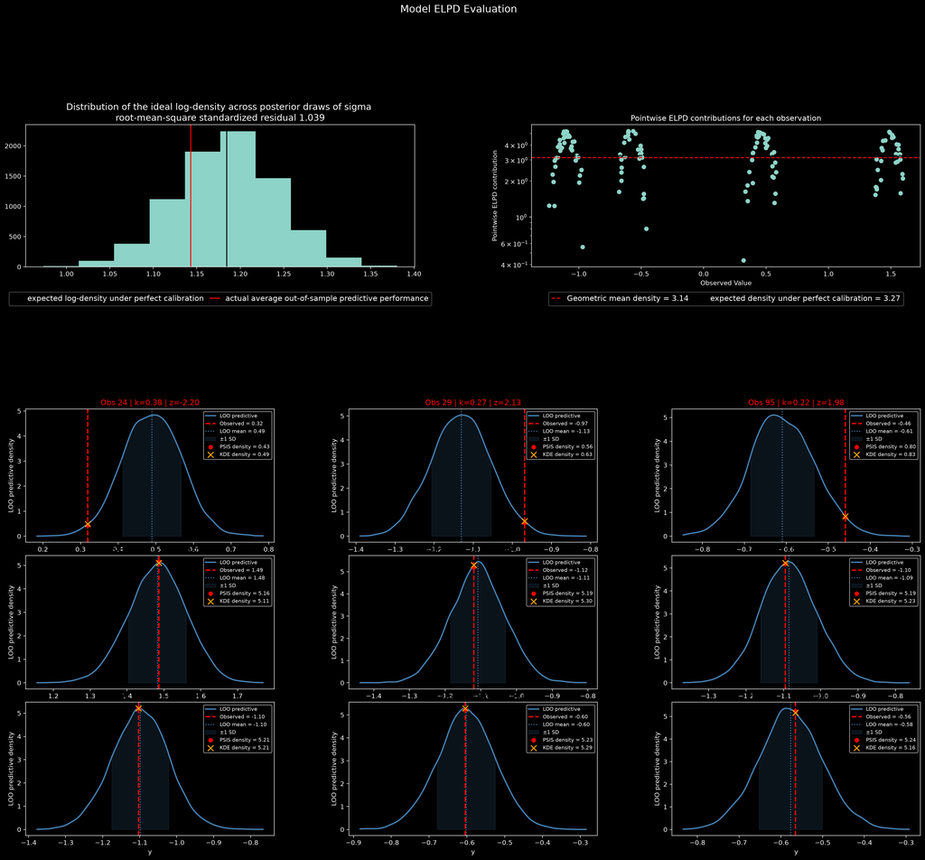

```python
fig_elpd, trouble_obs_indices = evaluate_model_elpd(
    idata_top_data.y_obs,
    out_pressure_loo,
    idata_top_data.sigma_stacked.to_numpy(),
    idata_top_data.y_pred_stacked.to_numpy(),
    weights,
    pareto_k,
)
```

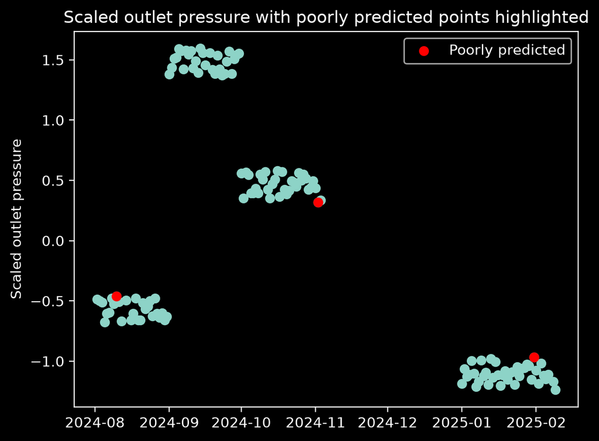

```python
plt.scatter(data_out_pressure.y_scaled.index, data_out_pressure.y_scaled)
plt.scatter(
    data_out_pressure.y_scaled.iloc[trouble_obs_indices].index,
    data_out_pressure.y_scaled.iloc[trouble_obs_indices],
    color="red",
    label="Poorly predicted",
)
plt.ylabel("Scaled outlet pressure")
plt.title("Scaled outlet pressure with poorly predicted points highlighted")
plt.legend()
plt.show()
```

# Bayesian LOO Diagnostic: Analytical Log-Density Calibration Check

## Overview

This diagnostic evaluates how well a Bayesian model's leave-one-out (LOO) predictive performance aligns with what we would theoretically expect from a perfectly calibrated Normal likelihood. By comparing the actual LOO log-density against an analytically derived "ideal" distribution, we can assess whether the model is well-calibrated, overconfident, or underconfident in its predictions.

## Method

### Deriving the Effective Standardized Residual

For a Normal likelihood, the log-density of a single observation is:

$$ \log p(y_i \mid \mu, \sigma) = -\frac{1}{2}\log(2\pi\sigma^2) - \frac{1}{2}\left(\frac{y_i - \mu}{\sigma}\right)^2 $$

Rearranging in terms of the average LOO log-density (ELPD / n), we can back-solve for the root-mean-square (RMS) standardized residual:

$$ \left|\frac{y - \mu}{\sigma}\right|_{\text{RMS}} = \sqrt{2\left(-\frac{1}{2}\log(2\pi\sigma^2) - \overline{\text{loo}}_{\log}\right)} $$

where $\overline{\text{loo}}_{\log}$ is the average pointwise LOO log-density. For a perfectly calibrated Normal model, the expected value of $(y - \mu)^2 / \sigma^2$ is 1.0, so the RMS z-score should be close to 1.

Using the posterior-average $\sigma$ and the computed ELPD, the resulting RMS z-score was **1.04** — very close to the ideal value of 1.0, with the small excess attributable to the expected penalty from out-of-sample (leave-one-out) prediction.

### Analytical Log-Density Distribution

To visualize this comparison, we compute the "ideal" per-observation log-density under the assumption of perfect calibration (RMS z-score = 1) across all posterior draws of $\sigma$:

$$ \ell_{\text{ideal}}(\sigma) = -\frac{1}{2}\log(2\pi) - \log(\sigma) - \frac{1}{2} $$

This yields a distribution of ideal log-densities that reflects posterior uncertainty in $\sigma$. We then overlay the actual average LOO log-density to see where it falls relative to this distribution.

## Results

### Analytical Log-Density Calibration

The histogram shows the distribution of analytical (ideal) log-densities across posterior samples of $\sigma$. The black vertical line marks the posterior mean of this distribution, and the red vertical line marks the actual average LOO log-density.

Key observations:

- **The LOO log-density (red) falls slightly to the left of the analytical mean (black)**, indicating that out-of-sample predictive performance is marginally worse than the in-sample ideal. This is expected behavior — LOO predictions leave each observation out, so a small degradation relative to the ideal is normal.
- **The LOO log-density lies well within the bulk of the analytical distribution**, meaning the observed out-of-sample performance is consistent with what the model's posterior uncertainty would predict under perfect calibration.
- **The RMS z-score of 1.04** corroborates this visual finding: the model's predictive distributions are neither too narrow (overconfident) nor too wide (underconfident).

### Pointwise ELPD Contributions

To examine the model's predictive performance at the individual observation level, we exponentiate the pointwise LOO log-densities to obtain the predictive density assigned to each observation:

$$ p(y_i \mid y_{-i}) = \exp(\text{elpd}_i) $$

These are plotted against the observed values on a log-scale y-axis, along with two reference lines:

- **Red dashed line (3.14)**: The geometric mean LOO density — the actual average out-of-sample predictive performance, computed as $\exp(\overline{\text{elpd}})$.
- **Black dashed line (3.26)**: The expected density under perfect calibration — what we would theoretically expect if every observation had an RMS z-score of exactly 1.0.

The small gap between the two reference lines (3.14 vs. 3.26, roughly a 3.7% decrease) represents the **out-of-sample prediction penalty** — the natural cost of predicting each observation without having seen it during fitting. This is entirely consistent with the RMS z-score of 1.04.

#### Interpreting the Scatter

Each point represents how well the model predicted that specific observation when it was left out. The density value can be thought of as a measure of "how surprised the model is" by that observation:

| Position | Meaning |
| --- | --- |
| Above the lines | The model found this observation **easy to predict** — it fell near the center of the LOO predictive distribution ($\\|z\\| < 1$) |
| Near the lines | The observation was about as surprising as a **typical draw** from a Normal distribution |
| Below the lines | The model found this observation **hard to predict** — it fell in the tails of the LOO predictive distribution ($\\|z\\| > 1$) |

This spread is **natural and expected**. Even for a perfectly calibrated Normal model, the standardized residuals $(y_i - \mu)/\sigma$ follow a standard Normal distribution, which means:

- ~38% of observations will have $|z| < 0.5$ → high density (above the lines)
- ~30% will have $0.5 < |z| < 1.0$ → near the lines
- ~24% will have $1.0 < |z| < 2.0$ → below the lines
- ~8% will have $|z| > 2.0$ → well below the lines

The reference lines represent average behavior — individual observations will always scatter around them.

#### What to Watch For

Signs of potential problems in a pointwise ELPD plot include:

| Pattern | Concern |
| --- | --- |
| Points below the line concentrated at specific observed values | Model misspecification in those regions |
| More low-density outliers than the expected ~8% | Heavier tails than the Normal likelihood assumes |
| Too little spread (all points on the line) | Possible overfitting or an overly flexible model |
| Systematic trend with observed value | Model is miscalibrated in certain regions of the outcome space |

#### Assessment

The pointwise ELPD plot shows healthy behavior:

- ✅ The scatter is **roughly symmetric** around the reference lines.
- ✅ There is **no systematic pattern** with the observed value — the model is not miscalibrated in any particular region.
- ✅ Only **2–3 points** fall notably below the bulk, consistent with normal tail behavior (~8% expected).
- ✅ The majority of observations cluster at or above the geometric mean density.
- ⚠️ Three observations drop below $10^0$ in density. These may warrant further investigation and cross-referencing with Pareto $\hat{k}$ diagnostics to ensure the LOO approximation is reliable for those points.

## Summary

| Metric | Value | Interpretation |
| --- | --- | --- |
| RMS z-score | 1.04 | Very close to ideal (1.0); minor out-of-sample penalty |
| Geometric mean LOO density | 3.14 | Close to ideal (3.26); 3.7% out-of-sample penalty |
| LOO position in analytical distribution | Within bulk | LOO performance consistent with posterior uncertainty |
| Pointwise scatter pattern | Homogeneous | No systematic miscalibration across observed values |

## Interpretation Guide

| RMS Z-Score | LOO vs. Analytical | Pointwise Pattern | Interpretation |
| --- | --- | --- | --- |
| ≈ 1.0 | Red line near black line | Symmetric scatter, few outliers | Well-calibrated model |
| >> 1.0 | Red line far left of distribution | Many points below the line | Overconfident or misspecified model |
| << 1.0 | Red line far right of distribution | Most points above the line | Underconfident model (overly wide predictions) |

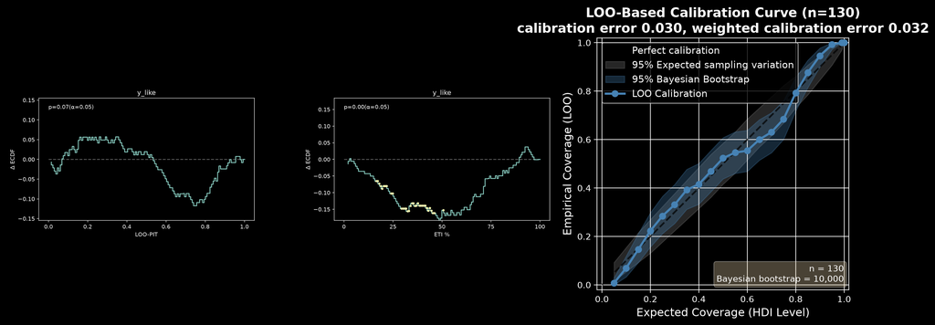

```python
fig_calibration, stats_calibration = plot_loo_calibration_curves(idata_top, RANDOM_SEED)
```

## Model calibration Assessment Summary

# Bayesian Model Evaluation: Understanding Uncertainty and Metrics

Assume a standard regression model:

$$y \sim \mathcal{N}(\mu, \sigma) \\ \mu = \mathcal{f}\left(X, \beta \right)=\beta_{0} + \beta_{1}.X_{1}+\beta_2.X_{2}+...$$

Two Types of Uncertainty

1. Posterior Uncertainty (Epistemic Uncertainty): Uncertainty about the model parameters ($\theta$)
2. Observation-Level Prediction Uncertainty (Aleatoric Uncertainty): Variability in predictions across different observations

$\text{trace}.\text{posterior}[\mu]$ is the deterministic noise function (expected value): $\mu=E[y | X, \theta]$

- No random noise included
- Pure systematic component
- Each draw $\mu_{d} = \mathcal{f}\left(X, \beta_{d} \right)$ where $d$ indexes the posterior draw.

$\text{trace}.\text{posterior\_predictive}[y_{obs}]$ is the full predictive distribution including observation noise: $$y_{pred} \sim \mathcal{N}(\mu, \sigma) \\ y_{pred} = \mu + \sigma.\epsilon \qquad \text{where} \quad\epsilon \sim \mathcal{N}(0, 1)$$

- Stochastic predictions (includes observation noise). Note the random seed provided for sampling, otherwise for a partcular draw, we can get different noise values.
- Full data-generating process
- Each draw represmets a complete observation (signal + noise): $y_{d}= \mathcal{f}\left(X, \beta_{d} \right) + \sigma_{d}.\epsilon_{d}$ where $d$ indexes the posterior draw.

Variance and Expected Value decomposition

$Var\left(y_{pred}\right)=Var\left(\mu\right) + Var\left(\sigma.\epsilon\right)[\sigma^2.Var\left(\epsilon\right)=\sigma^2.1]=Var\left(\mu\right)+\sigma^2$

- Var $\left(\mu \right)$: Epistemic uncertainty (parameter uncertainty) or variability due to systematic component (explained variance)
- $\sigma^2$: Aleatoric uncertainty (irreducible noise) or variability due to random noise (unexplained variance)
- Var $\left(y_{pred} \right)$: Total uncertanity

$E[y_{pred}] \left(E[\mu+\sigma.\epsilon]=E[\mu]+\sigma.E[\epsilon]=E[\mu]+\sigma.0 \right) = E[\mu] = \mu$

### Compare emprical σ to the model’s implied observation noise σ ($y_{obs} - \mu$)

Take important note that we should not use posterior predictive samples to calculate emprical residuals here as:

\begin{align*} y_{\mathrm{pred}} - y_{\mathrm{obs}} &= \left(\mu_{\mathrm{posterior}} + \sigma_{\mathrm{posterior}} \cdot \varepsilon_{\mathrm{pred}}\right) - \left(\mu_{\mathrm{true}} + \sigma_{\mathrm{true}} \cdot \varepsilon_{\mathrm{obs}}\right) \\ &= \left(\mu_{\mathrm{posterior}} - \mu_{\mathrm{true}}\right) + \left(\sigma_{\mathrm{posterior}} \cdot \varepsilon_{\mathrm{pred}} - \sigma_{\mathrm{true}} \cdot \varepsilon_{\mathrm{obs}}\right) \\ &= \text{systematic error} + \text{noise}_{\mathrm{pred}} - \text{noise}_{\mathrm{obs}} \end{align*}

\begin{align*} \text{Var}(y_{\mathrm{pred}} - y_{\mathrm{obs}}) &= \text{Var}(\mu_{\mathrm{posterior}} - \mu_{\mathrm{true}}) + \text{Var}(\sigma_{\mathrm{posterior}} \cdot \varepsilon_{\mathrm{pred}}) + \text{Var}(\sigma_{\mathrm{true}} \cdot \varepsilon_{\mathrm{obs}}) \\ &\approx \text{Var}(\mu_{\mathrm{posterior}} - \mu_{\mathrm{true}}) + \sigma_{\mathrm{posterior}}^2 + \sigma_{\mathrm{true}}^2 \end{align*}

If $\sigma_{posteriot} \approx \sigma_{true} \approx \sigma$: $$\text{Var}\left(y_{pred} - y_{obs}\right) \approx \text{Var}\left(\text{systematic error}\right) + 2 \sigma^2$$

To check our noise model, we need to use only posterior uncertanity as: \begin{align*} \left(\mu_{posterior} - y_{\mathrm{obs}}\right) &= \mu_{\mathrm{posterior}} -\left(\mu_{true} + \sigma_{\mathrm{true}} \cdot \epsilon_{obs}\right)\\ &= \left(\mu_{\mathrm{posterior}} - \mu_{\mathrm{true}}\right) - \sigma_{\mathrm{true}} \cdot \varepsilon_{\mathrm{obs}} \\ &= \text{systematic error} - \text{noise}_{\mathrm{obs}} \end{align*} Now if we get the variance: \begin{align*} \operatorname{Var}\left(\mu_{posterior} - y_{\mathrm{obs}}\right) &= \operatorname{Var}(\mu_{\text{posterior}} - \mu_{\text{true}}) + \operatorname{Var}(\sigma_{\text{true}} \cdot \varepsilon_{\text{obs}}) \\ &\approx \operatorname{Var}(\text{systematic error}) + \sigma_{\text{true}}^2 \end{align*}

Take important note that the raw $\sigma$ (dotted line) includes BOTH between-setpoint variance AND within-setpoint noise while the model $\sigma$ estimates only the within-setpoint noise after accounting for the mean function $\hat{\mu}$. For ideal calibration: The model $\sigma$ should capture the residual noise after accounting for $\mu$, NOT match the raw $\sigma$!

$$ \begin{align} \sigma_{\text{raw}} &= \sqrt{\sigma^2_{\mu} + \sigma^2_{\epsilon}} \\ \sigma_{\text{model}} &= \sigma_{\epsilon} \end{align} $$

$$ \begin{aligned} \text{Where:} \quad & \\ \sigma^2_{\mu} &= \text{variance explained by the mean function (between-setpoint)} \\ \sigma^2_{\epsilon} &= \text{residual variance (within-setpoint measurement noise)} \end{aligned} $$

$$ \begin{aligned} \text{Model estimate:} \quad & \sigma_{\text{model}} = E[\sigma \mid \text{data}] \\ \text{Empirical check:} \quad & \sigma_{\text{residual}} = \text{SD}(y - \hat{\mu}) \\ \text{Ideal calibration:} \quad & \sigma_{\text{model}} \approx \sigma_{\text{residual}} \end{aligned} $$

Why Bayesian R² Uses Posterior Uncertainty?

This is asking: "What is the distribution of R² values given my uncertainty about the parameters?" It's fundamentally about model uncertainty, not about individual predictions. For a given posterior draw of the model indexed $d$, what fraction of the variability across observations is explained by the model’s mean function? $$R^2 = \frac{\mathrm{Var}\left(\mu_d \right)}{\mathrm{Var}\left(\mu_d \right) + \mathrm{Var}\left(y_{obs}-\mu_d \right)}$$

```
===========================================================================
NOISE MODEL CALIBRATION DIAGNOSTICS
===========================================================================

📊 VARIANCE DECOMPOSITION:
---------------------------------------------------------------------------
  Total variance:              1501.01
  Between-setpoint:            1492.99  ( 99.5%)
  Within-setpoint (pooled):       8.02  (  0.5%)

  Overall R²: 0.995 (model captures between-setpoint variation)

📋 PER-SETPOINT DIAGNOSTICS:
---------------------------------------------------------------------------
  Setpoint | Model sigma | Residual sigma |  Ratio | Within R² |   Raw SD
---------------------------------------------------------------------------
        80 |     2.884 |       2.543 |   0.88 📉 |     8.5% |    2.700
       100 |     2.884 |       2.824 |   0.98 |    -5.5% |    2.824
       140 |     2.884 |       2.898 |   1.00 |     6.6% |    3.045
       180 |     2.884 |       2.804 |   0.97 |     6.6% |    2.952
---------------------------------------------------------------------------
      Mean |     2.884 |       2.767 |   0.96 |

===========================================================================
📖 INTERPRETATION:
===========================================================================

    The model has R² = 99.5% overall, but low within-setpoint R².

    This is EXPECTED and CORRECT because:

    1. 99.5% of total variance is BETWEEN setpoints
       → Model mean function (μ) captures this well ✓

    2. 0.5% of total variance is WITHIN setpoints
       → This is mostly irreducible noise (sensor noise, minor fluctuations)
       → Model sigma parameter captures this ✓

    The noise model evaluation above is checking whether model sigma correctly
    estimates this within-setpoint noise — and with mean ratio = 0.96,
    it does!

    ┌─────────────────────────────────────────────────────────────────────┐
    │  VERDICT: Well-specified model                                      │
    │  • Mean function captures systematic variation (between setpoints)  │
    │  • Sigma captures residual noise (within setpoints)                 │
    │  • Slight conservative bias (ratio < 1) is acceptable               │
    └─────────────────────────────────────────────────────────────────────┘
```

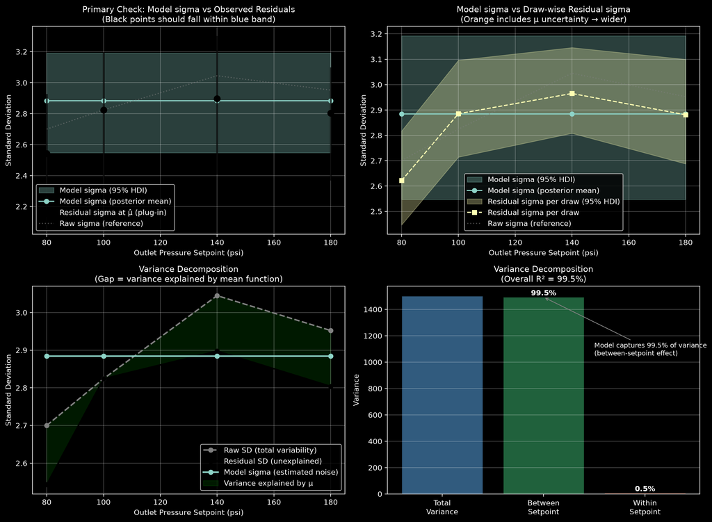

```python
model_non_hierarchical_sigma_eval = evaluate_noise_model(
    data_out_pressure,
    idata_top_data,
    std_unscaled,
    RANDOM_SEED,
)
```

### Demonstrate hierarchical sigma model

```
===========================================================================
NOISE MODEL CALIBRATION DIAGNOSTICS
===========================================================================

📊 VARIANCE DECOMPOSITION:
---------------------------------------------------------------------------
  Total variance:              1501.01
  Between-setpoint:            1492.99  ( 99.5%)
  Within-setpoint (pooled):       8.02  (  0.5%)

  Overall R²: 0.995 (model captures between-setpoint variation)

📋 PER-SETPOINT DIAGNOSTICS:
---------------------------------------------------------------------------
  Setpoint | Model sigma | Residual sigma |  Ratio | Within R² |   Raw SD
---------------------------------------------------------------------------
        80 |     2.922 |       2.507 |   0.86 📉 |    10.6% |    2.700
       100 |     2.924 |       2.837 |   0.97 |    -9.7% |    2.824
       140 |     2.925 |       2.912 |   1.00 |     4.7% |    3.045
       180 |     2.919 |       2.840 |   0.97 |     4.1% |    2.952
---------------------------------------------------------------------------
      Mean |     2.922 |       2.774 |   0.95 |

===========================================================================
📖 INTERPRETATION:
===========================================================================

    The model has R² = 99.5% overall, but low within-setpoint R².

    This is EXPECTED and CORRECT because:

    1. 99.5% of total variance is BETWEEN setpoints
       → Model mean function (μ) captures this well ✓

    2. 0.5% of total variance is WITHIN setpoints
       → This is mostly irreducible noise (sensor noise, minor fluctuations)
       → Model sigma parameter captures this ✓

    The noise model evaluation above is checking whether model sigma correctly
    estimates this within-setpoint noise — and with mean ratio = 0.95,
    it does!

    ┌─────────────────────────────────────────────────────────────────────┐
    │  VERDICT: Well-specified model                                      │
    │  • Mean function captures systematic variation (between setpoints)  │
    │  • Sigma captures residual noise (within setpoints)                 │
    │  • Slight conservative bias (ratio < 1) is acceptable               │
    └─────────────────────────────────────────────────────────────────────┘
```

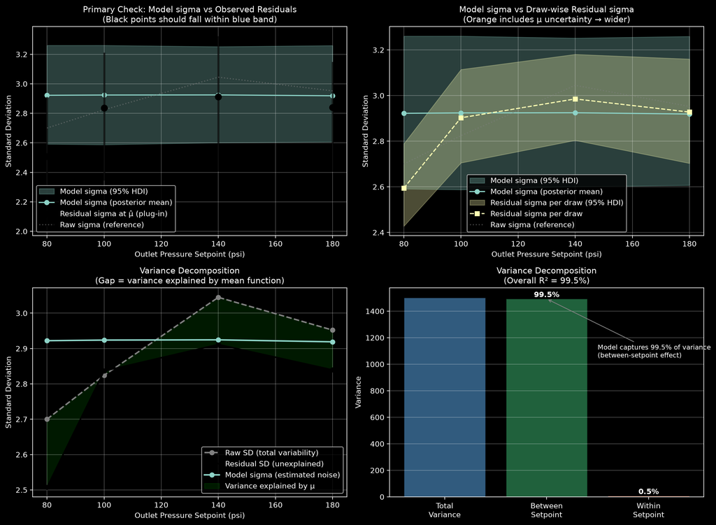

```python
idata_hierarchical_noise_data = exctract_pymc_groups_data(idatas_dict["hierarchical_noise"])

model_hierarchical_sigma_eval = evaluate_noise_model(
    data_out_pressure,
    idata_hierarchical_noise_data,
    std_unscaled,
    RANDOM_SEED,
)
```

# Posterior uncertanity versus pointwise predictive error for each observation

Posterior uncertanity captures: "How uncertain am I about the model's predictive performance?"

- Reflects uncertainty in the parameters (β coefficients, σ, etc.)
- Each draw represents a plausible model configuration
- The distribution shows how MAE varies across different plausible models
- Analogous to frequentist bootstrap uncertainty in performance metrics

While observation-level prediction uncertanity captures "Which individual predictions are more/less certain?"

- Shows which specific observations are hard to predict
- Uses the posterior mean (or median) as the point prediction
- The distribution is across observations, not posterior draws
- Useful for diagnostics and identifying outliers

The Analogy

Posterior uncertainty = "If I fit this model to different bootstrap samples, how much would my overall prediction errors vary?"

Observation uncertainty = "For this particular fitted model, which individual data points have larger prediction errors?"

```
Model performance:
Bayesian R²: bayesian_R2(mean=0.9945, hdi_lb=0.9932, hdi_ub=0.9957)
Residual R²: residual_R2(mean=0.9945, hdi_lb=0.9941, hdi_ub=0.9949)
Bayesian posterior MAE: mean=0.0846, 95% HDI=[0.07331699 0.09523073]
Bayesian pointwise MAE: mean=0.0624, 95% HDI=[0.00114591 0.11631073]
Arviz built-in MAE: mae(mean=0.0624, se=0.00299)
Bayesian posterior RMSE: mean=0.1045, 95% HDI=[0.091596   0.11708608]
Bayesian pointwise RMSE: mean=0.0711, 95% HDI=[0.06534484 0.07658385]
Arviz built-in RMSE: rmse(mean=0.0711, se=0.00287)
Leave-one-out Cross-validation adjusted R^2: loo_R2(mean=0.994, hdi_lb=0.9927, hdi_ub=0.9952)
Leave-one-out Cross-validation MAE: mae(mean=0.0674, se=0.00325)
Leave-one-out Cross-validation RMSE: rmse(mean=0.0769, se=0.00315)
```

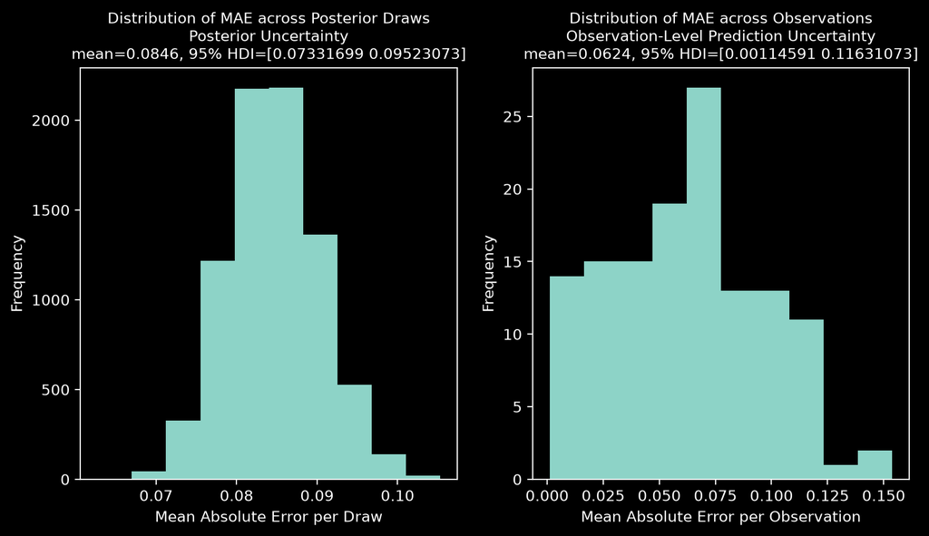

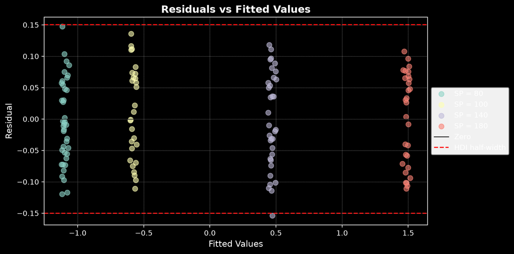

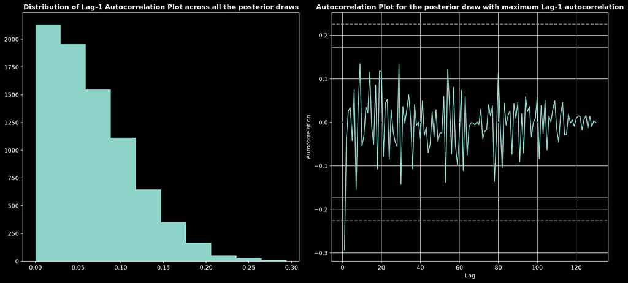

```python
_ = evaluate_model_performance(
    idata_top,
    idata_top_data,
    setpoint_timeseries=data_out_pressure.setpoint_timeseries,
    random_seed=RANDOM_SEED,
)
```

# Implement cusum

```python
X_full_scaled: pd.DataFrame = (X - data_out_pressure.X_mean) / data_out_pressure.X_std
y_full_scaled: pd.Series = (y - data_out_pressure.y_mean) / data_out_pressure.y_std
```

```python
with model_top:
    pm.set_data(
        {"X": X_full_scaled.to_numpy()},
        coords={"obs": np.arange(len(X_full_scaled))},
    )
    post_pred_full = pm.sample_posterior_predictive(
        idata_top, predictions=True, random_seed=RANDOM_SEED
    )
```

```
Sampling: [y_like]
```

```
Output()
```

```
Average HDI width: 0.3027075767123904
95% HDI coverage: 0.5805084745762712
```

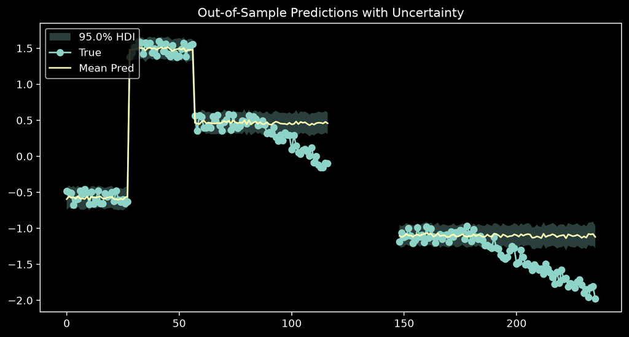

```python
y_pred_full_raw = post_pred_full.predictions["y_like"]
y_pred_full_raw.loc[{'obs': shutin_mask.to_numpy()}] = np.nan

plot_predictions_with_uncertainty(
    y_pred_full_raw,
    y_full_scaled.mask(shutin_mask).to_numpy(),
    y_pred_full_raw.stack(sample=("chain", "draw")).mean(axis=1)  # noqa: PD013 - stack() required for xarray dimension stacking
)
```

```python
residual_full_distribution = (
    y_full_scaled.to_numpy()
    - y_pred_full_raw.stack(sample=("chain", "draw")).T.to_numpy()  # noqa: PD013 - stack() required for xarray dimension stacking
)  # (chain * draw, n_obs)
full_data_timestamps: pd.DatetimeIndex = cast(pd.DatetimeIndex, y_full_scaled.index)
```

```python
# Calculate CUSUM for negative drift
uncertain_cusum_result = calculate_cusum_with_uncertainty(
    residuals_distribution=residual_full_distribution,
    timestamps=full_data_timestamps,
    shutin_mask=shutin_mask,
    baseline_mask=baseline_mask,
    anomaly_direction="neg",
    drift_multiplier=0.5,
    # n_samples_subset=1000  # Use 1000 samples for speed, or None for all
)
```

```
Target mean: -0.0000 ± 0.0092
Drift (k):   0.0521 ± 0.0033
```

```python
cusum_paths = uncertain_cusum_result.cusum_paths
cusum_mean = uncertain_cusum_result.mean
healthy_indices = np.where(baseline_mask)[0]
cusum_healthy = cusum_paths[:, healthy_indices]
# Maximum absolute CUSUM during healthy period (per sample)
max_cusum_healthy = np.max(np.abs(cusum_healthy), axis=1)

# Control limits as percentiles of max excursion
h_90 = np.percentile(max_cusum_healthy, 90)
h_95 = np.percentile(max_cusum_healthy, 95)
h_99 = np.percentile(max_cusum_healthy, 99)

print("\nControl Limits (from healthy period):")
print(f"  h_90: ±{h_90:.2f}")
print(f"  h_95: ±{h_95:.2f}")
print(f"  h_99: ±{h_99:.2f}")
```

```
Control Limits (from healthy period):
  h_90: ±0.47
  h_95: ±0.52
  h_99: ±0.63
```

```python
# Compute masked statistics
residual_stats = compute_masked_statistics(
    residual_full_distribution, full_data_timestamps, shutin_mask
)

# Compute exceedance probabilities
h = h_95  # Use 95th percentile control limit
p_above, p_below, p_either = compute_exceedance_probability(cusum_paths, h)


# Find first detection time (when probability exceeds threshold)
detection_threshold = 0.95  # Signal when 95% of samples exceed limit

# For positive drift (CUSUM going up)
detect_mask_lower = p_above > detection_threshold

if detect_mask_lower.any():
    first_detection = full_data_timestamps[detect_mask_lower][0]
    detection_idx = np.where(detect_mask_lower)[0][0]
    print("\n🚨 First anomaly detection (negative drift):")
    print(f"   Time: {first_detection}")
    print(f"   CUSUM mean at detection: {cusum_mean[detection_idx]:.2f}")
    print(f"   P(CUSUM > h): {p_above[detection_idx]:.1%}")
```

```
🚨 First anomaly detection (negative drift):
   Time: 2024-11-09 00:00:00+00:00
   CUSUM mean at detection: 0.93
   P(CUSUM > h): 96.4%
```

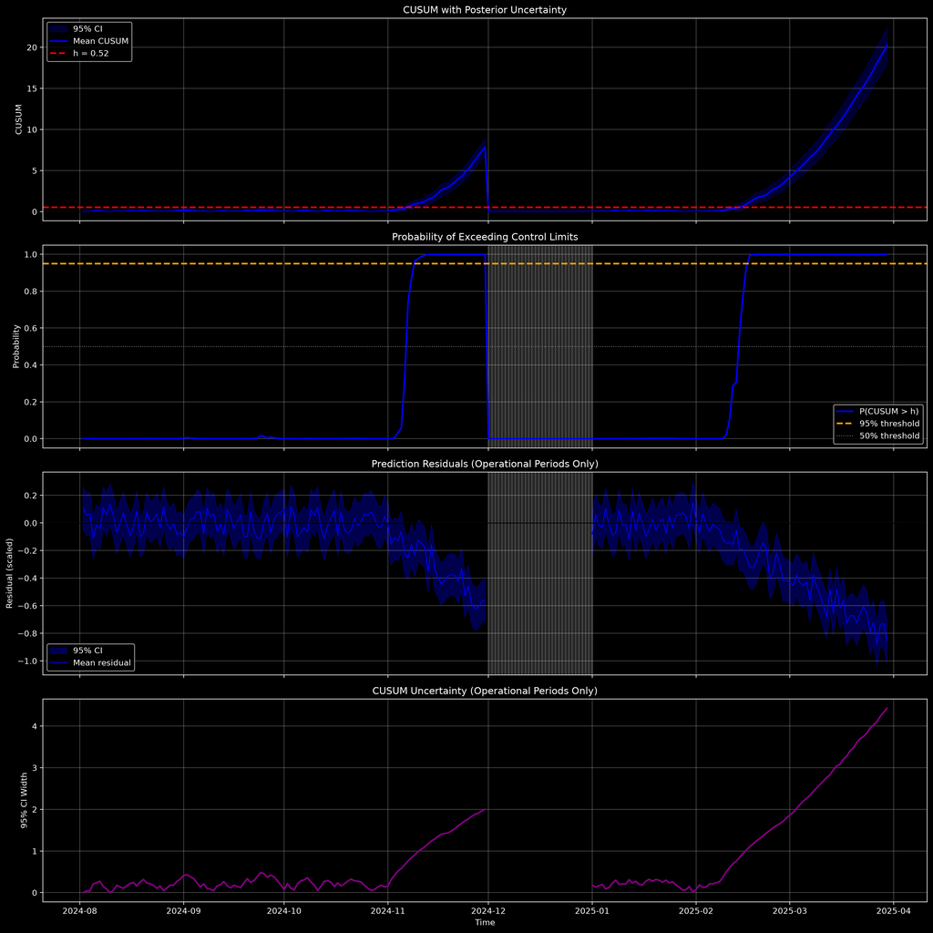

```python
fname = Path(IMAGE_DIR / "fouling_summary_probabilistic.png")
visualize_probabilistic_cusum(
    residual_stats, uncertain_cusum_result, full_data_timestamps, h_95, p_above, save=True, fname=fname
)
```

CUSUM Uncertainty Width Grows during anomaly periods (more uncertainty as CUSUM accumulates) and Resets after shutdown (as expected)

## Uncertainty-Aware CUSUM Results

### Key Advantages of Uncertainty-Aware CUSUM

1. **Memoryless after maintenance**: CUSUM correctly resets, avoiding false alarms
2. **Full uncertainty quantification**: 95% credible intervals on CUSUM paths
3. **Probabilistic detection**: Clear transition from 0% to 100% anomaly probability
4. **Validated baseline**: Per-sample parameters from calibrated Bayesian model